# 04 - metadata_d4a_d6a_to22

### Priority species - D6a

#### Total number of species

- the number of species,
- the number of species per group and
- the number of species per survey per group

```r
meta_d6   <- spp_d6a$freeman %>%
   dplyr::summarise(nspp = n_distinct(species),
      min_yr = min(year[!is.na(index)])[1],
      max_yr = max(year[!is.na(index)])[1]) %>%
  mutate(group = "ALL")

meta_d6_g <- spp_d6a$freeman %>%
     group_by(group) %>%
    dplyr::summarise(nspp = n_distinct(species),
      min_yr = min(year[!is.na(index)])[1],
      max_yr = max(year[!is.na(index)])[1]) %>%
    ungroup() %>%
  full_join(meta_d6)
meta_d61 <- spp_d6a$freeman %>%
     group_by(survey, group) %>%
    dplyr::summarise(nspp = n_distinct(species),
      min_yr = min(year[!is.na(index)])[1],
      max_yr = max(year[!is.na(index)])[1]) %>%
    ungroup() %>%
    full_join(meta_d6_g) %>%
    arrange(group, desc(nspp)) %>%
    select(group, survey, nspp, min_yr, max_yr ) %>%
    mutate(survey = ifelse(is.na(survey), "TOTAL", as.character(survey)))
meta_d61
```

```
## # A tibble: 20 × 5
##    group            survey    nspp min_yr max_yr
##    <chr>            <chr>    <int>  <int>  <int>
##  1 ALL              TOTAL      161   1970   2024
##  2 birds            TOTAL       44   1970   2024
##  3 birds            wbi         29   1970   2024
##  4 birds            rbbp         6   1973   2023
##  5 birds            wwbi         4   1975   2023
##  6 birds            up           3   1994   2024
##  7 birds            scar         2   1981   2023
##  8 bumblebees       beewalks     1   2010   2024
##  9 butterflies      ukbms       21   1976   2024
## 10 fish             fish         8   2000   2024
## 11 fw invertebrates fw_inv       2   2013   2024
## 12 mammals          TOTAL        8   1998   2024
## 13 mammals          nbmp         5   1998   2024
## 14 mammals          bbs_m        1   1998   2024
## 15 mammals          ndmp         1   1998   2024
## 16 mammals          nwvmp        1   2015   2024
## 17 moths            TOTAL       76   1970   2024
## 18 moths            ris         66   1970   2024
## 19 moths            prior_m     10   2000   2023
## 20 vascular plants  npms         1   2015   2024
```

```r
write.csv(meta_d61,    file = file.path(tidydataDir, "metadata_d6engto24_120326.csv"), row.names = FALSE)
```

#### Number of species per year

Let’s look at the number and proportion of species with values in the dataset in each year

- summarise across all species
- summarise by taxonomic group
- add in total number of species from meta… file above
- express all in relation to the total species

```r
sppyr_d6a <- spp_d6a$freeman %>%
  group_by(year) %>%
  dplyr::summarise(spp_yr = n_distinct(species[!is.na(index)]) ) %>%
  mutate(group = "ALL")
sppyr_grp_d6a <- spp_d6a$freeman %>%
  group_by(year, group) %>%
  dplyr::summarise(spp_yr = n_distinct(species[!is.na(index)])) %>%
  full_join(sppyr_d6a) %>%
  mutate(total_spp =
           meta_d6_g$nspp[match(group, meta_d6_g$group)]) %>%
  mutate(pspp = spp_yr/total_spp * 100)
```

save

```r
write.csv(sppyr_grp_d6a, file = file.path(tidydataDir, "spp_in_engd6ato24_peryr_120326.csv"))
```

plot

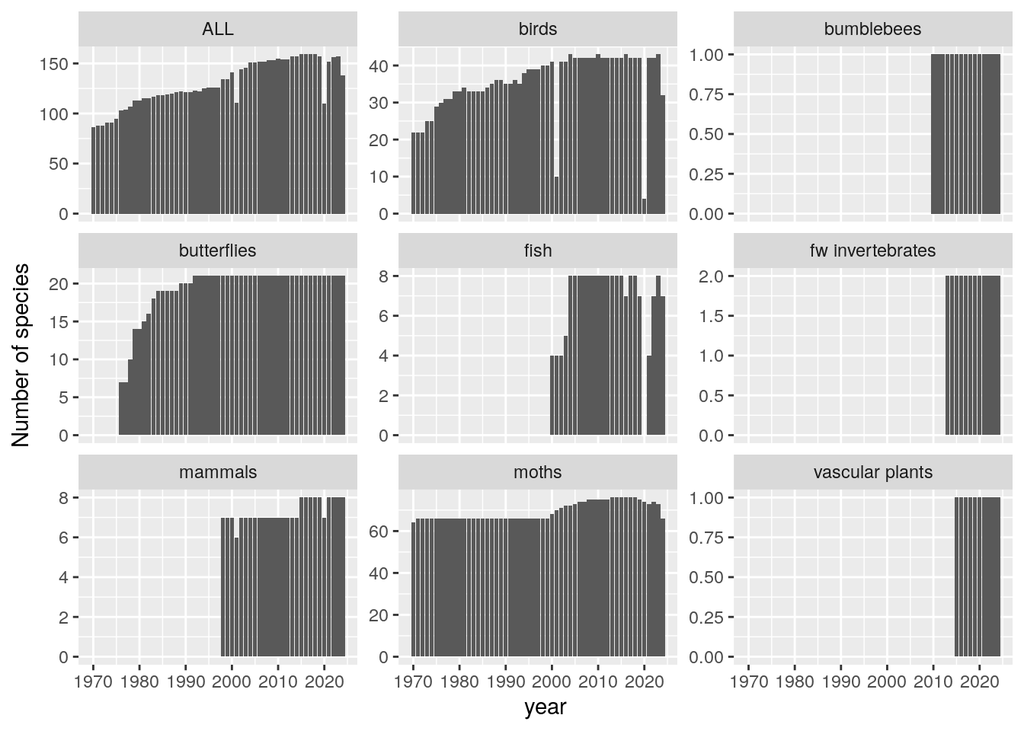

```r
p <- ggplot(sppyr_grp_d6a, aes(year, spp_yr)) +
  geom_col()+
  facet_wrap(vars(group), scales = "free_y")+
  ylab("Number of species")
p
```

```r
jpeg(7, 5, units = "in", file  = file.path(figDir_d6, "d6_engto24_spp_in_ind_grp.jpeg"), res = 500)
print(p)
dev.off()
```

## Extreme values

Let’s look at the number of extreme values

- save info on how often species time-series go below at 0.01 or above 100
- in order to do this we first rescale the time-series to start at 1 in their first year
- we don’t need to rescale to use the freeman method, this is just to assess extreme values and is not saved into the data used to run the indicator models on

function to count the number of extreme values

```r
no_cap <- function(data) {
  a_b <-  dplyr::summarise(data,
                    above100 = sum(index_m > 100, na.rm = TRUE),
                    below0.01 = sum(index_m < 0.01, na.rm = TRUE))
return(a_b)
}
```

##### Function now in ‘tidying_functions.R’

- function to rescale species’ time-series relative to the value in the first year [rescale]

Estimate the number of rapidly increasing or decreasing species

```r
ext_trd_d4a  <- spp_d4a$freeman %>%
    rename(scientific_name = species) %>%
    rescale(ind_col = index_m, Index_root = 1) %>%
    group_by(group, scientific_name, common_name) %>%
    no_cap() %>%
    filter(!(above100 == 0 & below0.01 ==0))
ext_trd_d6a <- spp_d6a$freeman %>%
  rename(scientific_name = species) %>%
    rescale(ind_col = index_m, Index_root = 1) %>%
    group_by(group, scientific_name, common_name) %>%
    no_cap() %>%
    filter(!(above100 == 0 & below0.01 ==0))
write.csv(ext_trd_d4a,
          file = file.path(tidydataDir, "d4a_engto24_spp_a100_b0.001_120326.csv"),
          row.names = FALSE)

write.csv(ext_trd_d6a,
          file = file.path(tidydataDir, "d6a_engto24_spp_a100_b0.001_120326.csv"),
          row.names = FALSE)
```

## Number of zeros or psuedo-zeroes

Zeros are difficult to deal with in indicator models and we use a rule of thumb workaround to address this. Good to assess:

- the number of species affected
- the number of instances

```r
zrs_d4 <- spp_d4a$freeman %>%
  group_by(survey, species, common_name) %>%
  summarise(zero_psuedozero = sum(index_orig == 0, na.rm = TRUE)) %>%
  filter(zero_psuedozero != 0)
zrs_d6 <- spp_d6a$freeman %>%
  dplyr::group_by(survey, species, common_name) %>%
  dplyr::summarise(zero_psuedozero = sum(index_orig == 0, na.rm = TRUE)) %>%
  filter(zero_psuedozero != 0)
write.csv(zrs_d4,
          file.path(tidydataDir, "d4_engto24_zero_psuedozeros_inspptrends_120326.csv"),
          row.names = FALSE)

write.csv(zrs_d6,
          file.path(tidydataDir, "d6_engto24_zero_psuedozeros_inspptrends_120326.csv"),
          row.names = FALSE)
```